# COVIDMINDER Bootcamp Notebook

John Erickson

4/28/2020

## INTRODUCTION

This R Notebook and its related R scripts provide an introduction to the **COVIDMINDER** application, which you can find at:

- Public “production” version: https://covidminder.idea.rpi.edu/
- Public “pre-release” version: https://bit.ly/COVIDMinder

The github repository for all the code required for this notebook, including a snapshot of the **COVIDMINDER** application, can be found at:

- https://github.com/TheRensselaerIDEA/COVID-Notebooks

The **COVIDMINDER** github repository can be found at:

- https://github.com/TheRensselaerIDEA/COVID-DI-Prototype

## HOW TO USE THIS NOTEBOOK AND REPOSITORY

We’re asking those who wish to participate in this excercise to clone the github repository, create a personal branch, and make additions to the repository by creating new, customized notebooks. The general procedure is as follows:

- `git clone https://github.com/TheRensselaerIDEA/COVID-Notebooks.git` in your `home` directory, creating a new directory `COVID-Notebooks`
- In the Linux shell, `cd` to `COVID-Notebooks`
- In the Linux shell, `git checkout -b feature-id` where `id` is the github issue number your branch will address
  - If you are working on `Issue #99`, your new branch should be `feature-99`
  - If someone else is already working on #99 and you want to also, separately, call your branch `feature-99-1`
  - Following this convention is **critical**!
- In RStudio Server, navigate to `COVID-Notebooks` via the **Files** panel
- Set this to be your R working directory
- One approach: Make a **copy** of this notebook (ie `Rmd`) file using an *original, descriptive* filename
- Another approach: Create an entirely new, fresh notebook.
- In either case, use the data we’ve provided under the `data/csv` subdirectory.
- edit…knit (to HTML)…repeat
- In Linux, `git add` each file you want to add to the repository (e.g. your new `Rmd` file, perhaps the `html` you create when you knit)
- When you’re ready, in Linux `git commit -a -m "some comment"` where “some comment” is a useful comment describing your changes
- Finally, `git push origin feature-id` (where `feature-id` is the branch you’re working on)
- …and then go to github and submit a pull request.

Please also see this handy github “cheatsheet”: https://education.github.com/git-cheat-sheet-education.pdf

## UNDERSTANDING THE DATA

- All of the data used for this notebook and the **COVIDMINDER** app is located in the `data/` directory hierarchy, mostly under `data/csv/` and `data/csv/time_series/`
- Feel free to browse the directory tree using RStudio or on the web via github
- Most of the nationwide data is under `data/csv`
- Most of the nationwide time series data and New York per-county data is under `data/csv/time_series/`
  - This layout may change
- We will be expanding our data archive, esp. using social determinatns data from **County Health Rankings**
  - See https://www.countyhealthrankings.org/explore-health-rankings/measures-data-sources/2020-measures

## WHAT SHOULD I WORK ON?!?!?

- Choose an existing issue: https://github.com/TheRensselaerIDEA/COVID-Notebooks/issues
  - Ask questions about the issue in the “Comments” section of that issue
  - “Claim” the issue by self-assigning
- OR, create your own issue; click “New Issue”
- OR, ask Prof. Bennett or Dr. Erickson for an issue to work on!

## HOW TO SHARE YOUR WORK OR ASK QUESTIONS

- Use the `idea_covid-19` stack channel under The Rensselaer IDEA
  - Contact Dr. Erickson to be added (if you haven’t already)

## WHAT TO INCLUDE IN YOUR NOTEBOOK

- The code in your notebook should be well commented
- You should include thorough discussions of your methods and explanations of your results in the **markdown** sections (the non-code sections)
- You should always include enough detail for someone else to reproduce (and re-use!) your work!
- **ALWAYS* include useful titles and legends for your plots and tables!
- Nicely-formatted tables are always a bonus
- Your “default” for knitting notebooks should be HTML; this makes it easier to view and reduces errors.

#### **EXPLANATION OF VISUALIZATIONS:**

The goal of these visualizations is to examine nationwide disparities in COVID-19 factors having to do with risks, mediations (e.g. testing, hospital beds), and outcomes (e.g. deaths, cases). A common measure, the *disparity index* is used to represent the difference between the observed rate in the state and some baseline rate.

The advantage of the disparity index is that represents how far off a target standard the observed rate is.

Mathematically, `DI = log(x/y)` or `DI = log(y/x)` depending upon whether being above or below the target is preferred.

- In the case of hospital beds or rate of testing, *x* would be some state’s rate , and *y* would be the US rate or some rate we’re comparing against (e.g. South Korea’s testing or Italy’s hospital beds).
- In the case of mortality rates, *x* would be the target rate (e.g. some national rate, including the US), and *y* would be the individual state’s rate.

#### **How do COVID-19 mortality rates compare across the United States?**

*This map compares the COVID-19 mortality rates of individual states with the US rate. This map is updated daily.*  
Here, **shades of red** indicate that a state’s COVID-19 mortality rate is higher than the US rate  
Data source: [JHU daily reports](https://bit.ly/3dMWRP6) (04-07-2020)

[interactive chart not shown]

#### **How do COVID-19 testing rates across the US compare with South Korea?**

*This map compares rates of COVID-19 tssting in US states vs South Korea’s testing rate. This map is updated daily.*  
Here, **shades of red** indicate that a state’s testing rate is lower than the South Korean rate  
Data source: [The COVID Tracking Project daily reports](https://covidtracking.com/api) (04-07-2020)

[interactive chart not shown]

#### **How do cardiovascular mortality rates across the US compare with the national average?**

*The map compares individual state mortality rates related to cardiovascular diseases (per 100k) with the US rate. In recent literature, COVID-19 risk has been linked to certain cardiovascular diseases, including hypertension. This map uses recent historical figures.*  
Here, **shades of red** indicate that a state’s mortality rate from total cardiovascular diseases is **higher** than the US rate  
Data source:  
[CDC (2017)](https://bit.ly/2V1Zl3I)

[interactive chart not shown]

#### **How does the availability of hospital beds across the United States compare with Italy?**

*This map compares the availability of hospital beds in US states vs the rate in Italy (3.2 beds/1000). This map uses recent historical figures and does not reflect ‘surge’ capacity.*  
Here, **shades of red** indicate that a state’s hospital bed availablity is lower than the rate in **Italy**  
Data sources:  
[Organisation for Economic Co-operation and Development](https://data.oecd.org/healtheqt/hospital-beds.htm) and [Kaiser Family Foundation](https://bit.ly/2V0CYLU)

[interactive chart not shown]

#### **How do COVID-19 mortality rates compare across New York State?**

*This map compares the COVID-19 mortality rates of NY counties with the NY average. This map is updated daily.*  
Here, **shades of red** indicate that a county’s COVID-19 mortality rate is higher than the NY rate.  
Data source: [JHU daily reports](https://bit.ly/3dMWRP6) (04-06-2020)

[interactive chart not shown]

#### **How do COVID-19 cases compare across New York State?**

*This map compares the COVID-19 cases for NY counties with the NY average. This map is updated daily.*  
Here, **shades of red** indicate that a county’s COVID-19 case count is higher than the NY rate.  
Data source: [JHU daily reports](https://bit.ly/3dMWRP6) (04-06-2020)

[interactive chart not shown]

Determinant: What are the disparities between New York counties in the rate of diabetes patients per 100k population when compared to the average United States rate?

Diabetes puts patients at increased risk of contracting and dying from COVID-19, so areas with higher diabetes rates may face increased COVID-19 burdens.  
The rate of diabetes patients per 100k in a county is

*Darker shades indicate greater disparity.*  
**Diabetes Rate** = number of diabetic patients per 100K population  
**Diabetes Disparity Index** = log(Diabetes Rate in state/average Diabetes Rate in US)  
**Date:** 2020  
**DATA SOURCE:** [County Health Rankings](https://bit.ly/34mYLBP) and [CDC](https://bit.ly/2V1Zl3I)

[interactive chart not shown]

#### **How have COVID-19 cases increased across New York State?**

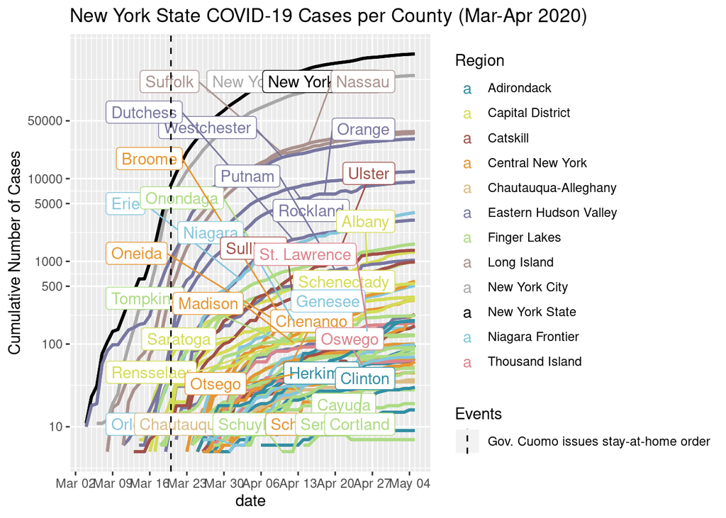